# Statistical machine learning, Lab 12

#Selecting classification methods by different measures

In this lab we consider classification methods which are related to probability estimation.

If we have a nominal outcome variable with a small number of different values, then we may want to a) estimate the probabilities of different outcomes for each set of predictor values (that is, we want to estimate probability distribution of outcomes); b) assign a predicted outcome value for each set of predictor values.

A common measure for assessing the fit of a probability measure estimates is logarithmic likelihood of data and the function for computing corresponding loss in `tidymodels` framework is `mn_log_loss()` defined in `yardstick` package.

If we want to use a model which provides probability estimates for classification and we know the loss function of misclassifications, then we can assign class by the rules of Bayes classifier. If our probability model is correct, then this is the best possible classifier minimizing expected loss. If our model is not very accurate, then the rules of Bayes classifier may not give the best result, but we still may get very good results in classification by considering ROC curve (or ROC curves in multiclass case) and determining the optimal decision rules from those curves.

Finally, if we want to select a method which leads to good classification rules for many different classification loss functions, then we may look at AUC measures (computed by `roc_auc()`)

In this lab we consider `Default` data set from `ISLR` library, the outcome variable is `default`.

Let us consider using logistic regression, quadratic discriminant analysis, generalized additive model and kNN.

### **Exercise 1**

```r
set.seed(20241121)
split=initial_split(Default,strata = default)
train_df=training(split)
compare_df=testing(split)
cv_data=vfold_cv(train_df,strata=default)
```

## Fitting models for probability prediction

### **Exercise 2**

Fit logistic regression, QDA and generalised additive models (gam with a smoothing term with respect to `income`) to training set and compute mean log loss on the comparison set. Which one has the smallest loss? Hint: when computing mean log loss, it is a good idea to indicate with `event_level="first/second"`, which level of the outcome variable corresponds to the event for which we provide probabilities.

*Solution:*

```r
  spec_logreg=logistic_reg()
  spec_qda=discrim_quad()
  rec=recipe(default~.,data=train_df)
  wf_logreg=workflow()|>add_recipe(rec)|>add_model(spec_logreg)
  wf_qda=workflow()|>add_recipe(rec)|>add_model(spec_qda)
  wf_final_qda=wf_qda|>fit(train_df)
  wf_final_logreg=wf_logreg|>fit(train_df)
  comparison_df=augment(wf_final_logreg,compare_df)|>mn_log_loss(default,.pred_Yes,event_level="second")|>mutate(method="logistic regression")
  comparison_df=augment(wf_final_qda,compare_df)|>mn_log_loss(default,.pred_Yes,event_level="second")|>mutate(method="QDA")|>rbind(comparison_df)
  wf_gam=workflow()|>add_recipe(rec)|>add_model(gen_additive_mod(mode="classification"),formula=default~student+balance+s(income))
  wf_final_gam=wf_gam|>fit(train_df)
  comparison_df=augment(wf_final_gam,compare_df)|>mn_log_loss(default,.pred_Yes,event_level="second")|>mutate(method="GAM")|>rbind(comparison_df)
  comparison_df|>arrange(.estimate)
```

| .metric | .estimator | .estimate | method |
| --- | --- | --- | --- |
| mn_log_loss | binary | 0.07366807 | logistic regression |
| mn_log_loss | binary | 0.07425923 | GAM |
| mn_log_loss | binary | 0.07632428 | QDA |

### **Exercise 3**

If we want to use kNN for probability estimation, we should make sure that the number of neighbors is large enough to get reasonable probability estimates. Use cross-validation data to select appropriate number of neighbors from 11,21,31 for predicting probability of default. Compute mean log loss on the test set.

*Solution:*

```r
wf_knn=workflow()|>add_recipe(rec)|>add_model(nearest_neighbor(mode="classification",neighbors=tune()))
tune_results=wf_knn|>tune_grid(cv_data,grid=data.frame(neighbors=c(11,21,31)),metrics=metric_set(mn_log_loss))
show_best(tune_results,metric="mn_log_loss")
```

| neighbors | .metric | .estimator | mean | n | std_err | .config |
| --- | --- | --- | --- | --- | --- | --- |
| 31 | mn_log_loss | binary | 0.1722444 | 10 | 0.02465231 | Preprocessor1_Model3 |
| 21 | mn_log_loss | binary | 0.2209681 | 10 | 0.02886364 | Preprocessor1_Model2 |
| 11 | mn_log_loss | binary | 0.2986698 | 10 | 0.03111113 | Preprocessor1_Model1 |

```r
wf_final_knn=wf_knn|>finalize_workflow(select_best(tune_results,metric="mn_log_loss"))|>fit(train_df)
comparison_df=augment(wf_final_knn,new_data=compare_df)|>mn_log_loss(default,.pred_Yes,event_level="second")|>mutate(method="kNN")|>rbind(comparison_df)
comparison_df|>arrange(.estimate)
```

| .metric | .estimator | .estimate | method |
| --- | --- | --- | --- |
| mn_log_loss | binary | 0.07366807 | logistic regression |
| mn_log_loss | binary | 0.07425923 | GAM |
| mn_log_loss | binary | 0.07632428 | QDA |
| mn_log_loss | binary | 0.22799315 | kNN |

```r
#If we want to use kNN for probability estimation, it is useful to replace 0 and 1 predictions with more conservative ones, like 1/(2*k) and 1-(1/(2*k)), where k is the nubmer of neighbors used
augment(wf_final_knn,new_data=compare_df)|>mutate(.pred_Yes=pmax(pmin(.pred_Yes,61/62),1/62))|>mn_log_loss(default,.pred_Yes,event_level="second")
```

| .metric | .estimator | .estimate |
| --- | --- | --- |
| mn_log_loss | binary | 0.08743037 |

```r
#log-loss value on new data is reduced significantly.
```

### **Exercise 4**

Produce plots of ROC curves for QDA and kNN based on performance on the comparison set. Compute data for ROC curve by using the test set with `roc_curve()` and use it to produce graph of ROC curve. Note that inside the the `roc_curve()` it is necessary to indicate, which level or the response is the positive result with event_level=“first/second” option; the resulting plot can be created with `autoplot()` command.

*Solution:*

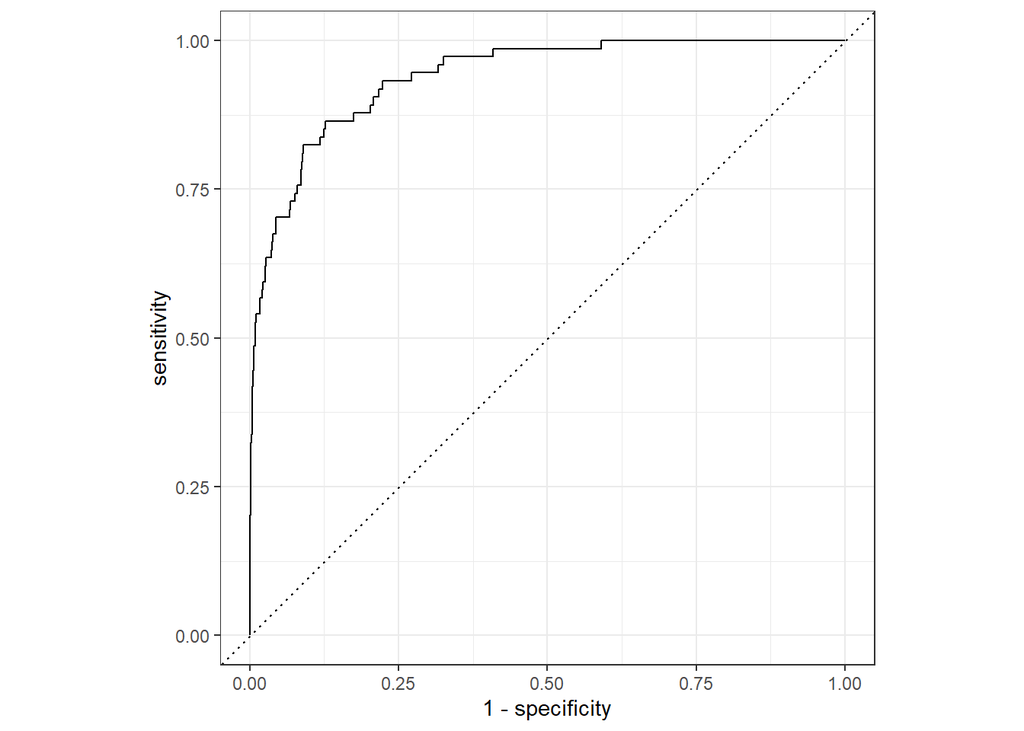

```r
roc_qda=augment(wf_final_qda,compare_df)|>roc_curve(default,.pred_Yes,event_level="second")
plot1=autoplot(roc_qda)
plot1
```

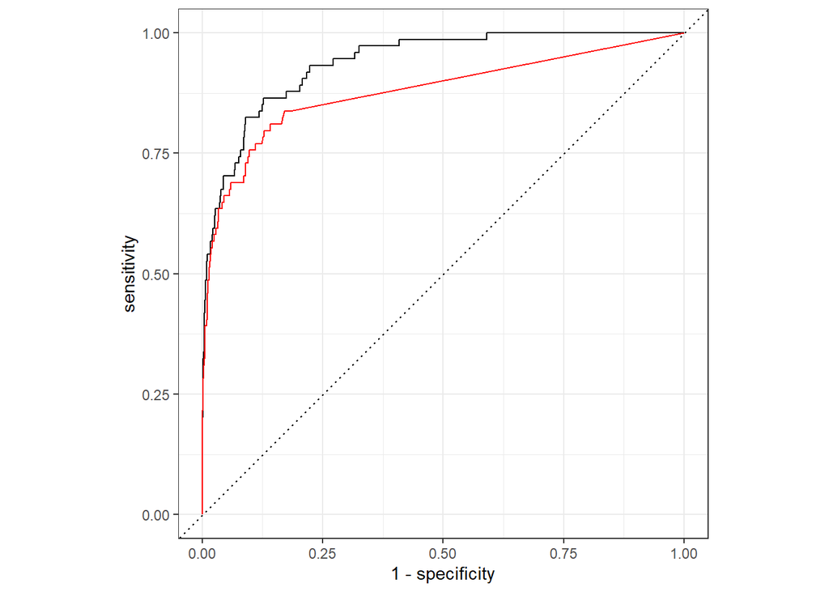

```r
roc_knn=augment(wf_final_knn,compare_df)|>roc_curve(default,.pred_Yes,event_level="second")
plot1+geom_path(data=roc_knn,aes(x=1-specificity,y=sensitivity),color="red")
```

```r
#AUC computation example
augment(wf_final_knn,new_data=compare_df)|>roc_auc(default,.pred_Yes,event_level="second")
```

| .metric | .estimator | .estimate |
| --- | --- | --- |
| roc_auc | binary | 0.8787404 |

### **Exercise 5**

Consider the case when predicting “No” for defaulting application costs 5 times more than predicting “Yes” for application which does not default. Which probability level should we use in Bayes classificator in this case? Compute the classification losses of the classifies constructed from previously fitted methods on the comparison data. Which point on a ROC curve of QDA method computed for training data corresponds to the optimal split?

*Solution:* If we want to minimize loss in the case when the predicting no default for loan that actually defaults is 5 times more costly than the opposite wrong classification, we should look at the formula for the expected loss:
$$E[L(Y,\hat{y})]=P(Y=0)E(\hat{y}=1\mid Y=0)+5
P(Y=1)E(\hat{y}=0\mid Y=1)$$
The values can be estimated from data - $P(Y=0)$ corresponds to the fraction of no default (I estimated this from the full data set), $E(\hat{y}=1\mid Y=0)$ can be estimated by (1-specifity) (or false positive rate), the second term $E(\hat{y}=0\mid Y=1)$ corresponds to (1-sensitivity). So the best point (x,y) on ROC curve should minimize the function
$$0.9667x+5\cdot
0.0333(1-y).$$

```r
roc_qda_training=augment(wf_final_qda,train_df)|>roc_curve(default,.pred_Yes,event_level="second")
roc_qda_training|>mutate(x=1-specificity,y=sensitivity,fn_value=0.9667*x+5*0.0333*(1-y))|>filter(fn_value==min(fn_value))
```

| .threshold | specificity | sensitivity | x | y | fn_value |
| --- | --- | --- | --- | --- | --- |
| 0.1918546 | 0.9611932 | 0.6718147 | 0.03880679 | 0.6718147 | 0.09215739 |

So by deciding based on the training data, the best cut-off value should be 0.192 for the probability of default and this corresponds to the point (0.0388,0.672) on the graph. Bayes cutoff is $\frac{1}{6}$, so in the case of QDA we may get better results by using a slightly different cutoff value.

```r
augment(wf_final_qda,compare_df)|>mutate(.pred_class=factor(if_else(.pred_Yes>=1/6,"Yes","No"),levels=c("No","Yes")))|>
  mutate(loss=if_else(default==.pred_class,0,if_else(default=="Yes",5,1)))|>
  pull(loss)|>mean()
```

```
## [1] 0.088
```

```r
augment(wf_final_qda,compare_df)|>mutate(.pred_class=factor(if_else(.pred_Yes>=0.192,"Yes","No"),levels=c("No","Yes")))|>
  mutate(loss=if_else(default==.pred_class,0,if_else(default=="Yes",5,1)))|>
  pull(loss)|>mean()
```

```
## [1] 0.0848
```

We see that on the comparison data modified cutoff level gives slightly smaller loss value. Using Bayes cutoff with logistic regression gives the following loss on the comparison data:

```r
augment(wf_final_logreg,compare_df)|>mutate(.pred_class=factor(if_else(.pred_Yes>=1/6,"Yes","No"),levels=c("No","Yes")))|>
  mutate(loss=if_else(default==.pred_class,0,if_else(default=="Yes",5,1)))|>
  pull(loss)|>mean()
```

```
## [1] 0.0848
```

So Bayes cutoff works better with logistic regression that with QDA model. This is expected since logistic regression approximated probabilities better than QDA.